# Practica 1

Mike

2023-03-15

# Suavizacion exponencial

Vamos analizar las ventas de 3 empresas para pronosticar los siguientes 10 años. Estos datos fueron obtenidos de factset y son series anuales.

Iniciamos de la manera estándar:

```r
rm(list=ls())
setwd("~/Documents/suavizacion")

library(forecast)
library(readxl)
library(tidyverse)
```

Recordando: * Suavización simple es útil si la serie de tiempo no tiene estacionalidad ni tendencia, por eso los pronósticos son planos. * Método de holt es útil si la serie de tiempo no tiene estacionalidad pero si tiene tendencia, la tendencia es infinita (siempre aumenta o disminuye) * Método de holt amortiguado es útil no tiene estacionalidad pero si tendencia pero esa tendencia no es infinita

Vamos a cargar los datos

```r
coca <- read_excel("coca.xlsx")
walmart <- read_excel("walmart.xlsx")
netflix <- read_excel("netflix.xlsx")
```

Generamos las series de tiempo:

```r
coca <- ts(coca$`Coca-Cola Sales`, start = 1980, frequency = 1)
netflix <- ts(netflix$`Netflix Sales`, start = 2002, frequency = 1)
walmart <- ts(walmart$`Walmart Sales`, start = 1981, frequency = 1)
```

## Coca

Iniciamos el analisis grafico

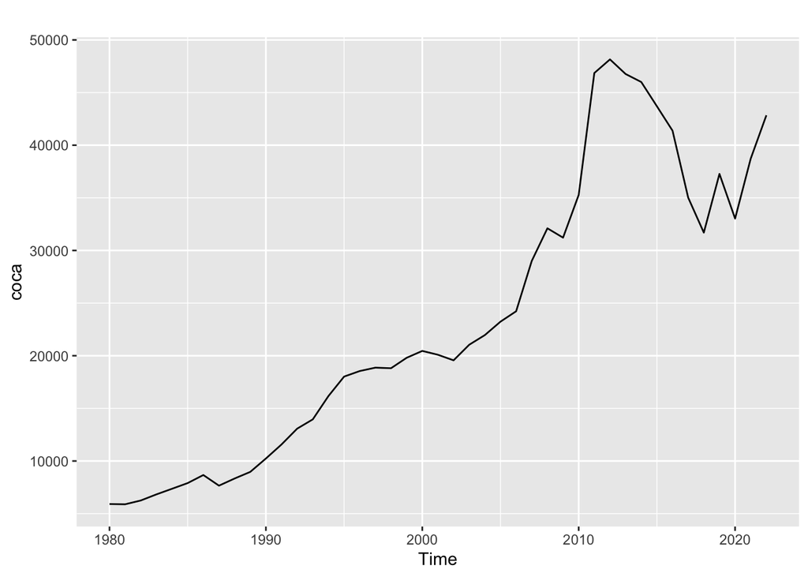

```r
autoplot(coca)
```

Dado el comportamiento de esta serie, se recomienda utilizar el método de holt.

```r
pronostico_coca <- holt(coca, h=10)
```

Analizamos los resultados: Si lo quiero la tabla de datos, basta con poner el poner el nombre del objeto. De manera predeterminada, R realiza los pronosticos con un intervalo de confianza al 80% y 95%.

```r
pronostico_coca
```

```
##      Point Forecast    Lo 80    Hi 80    Lo 95    Hi 95
## 2023       43587.71 39786.07 47389.36 37773.60 49401.83
## 2024       44335.58 38959.90 49711.27 36114.18 52556.98
## 2025       45083.45 38499.66 51667.25 35014.41 55152.50
## 2026       45831.32 38228.85 53433.80 34204.34 57458.30
## 2027       46579.19 38079.09 55079.29 33579.41 59578.98
## 2028       47327.06 38015.31 56638.82 33085.96 61568.16
## 2029       48074.93 38016.67 58133.20 32692.14 63457.72
## 2030       48822.80 38069.59 59576.01 32377.19 65268.42
## 2031       49570.67 38164.66 60976.69 32126.68 67014.67
## 2032       50318.54 38294.99 62342.09 31930.11 68706.98
```

Graficamos el pronostico

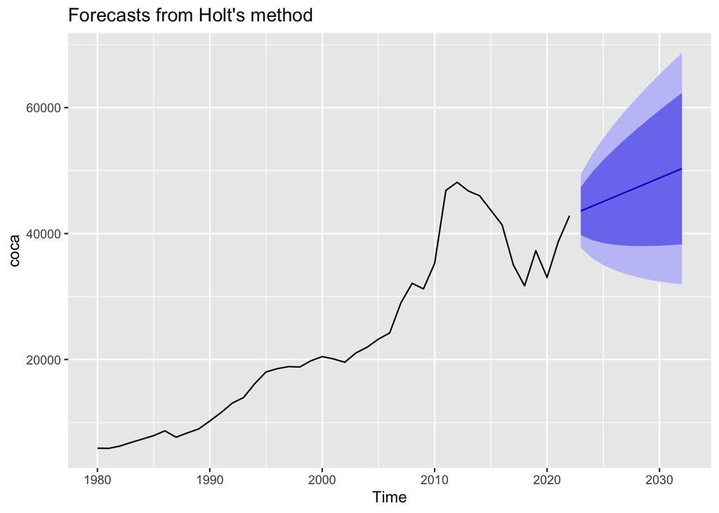

```r
autoplot(pronostico_coca)
```

Analizamos los parámetros de la estimación

```r
summary(pronostico_coca)
```

```
##
## Forecast method: Holt's method
##
## Model Information:
## Holt's method
##
## Call:
##  holt(y = coca, h = 10)
##
##   Smoothing parameters:
##     alpha = 0.9997
##     beta  = 1e-04
##
##   Initial states:
##     l = 5453.5353
##     b = 747.3452
##
##   sigma:  2966.439
##
##      AIC     AICc      BIC
## 855.1133 856.7349 863.9193
##
## Error measures:
##                   ME     RMSE      MAE        MPE     MAPE      MASE      ACF1
## Training set 122.016 2825.098 1772.375 -0.5492149 6.575582 0.8855129 0.1810455
##
## Forecasts:
##      Point Forecast    Lo 80    Hi 80    Lo 95    Hi 95
## 2023       43587.71 39786.07 47389.36 37773.60 49401.83
## 2024       44335.58 38959.90 49711.27 36114.18 52556.98
## 2025       45083.45 38499.66 51667.25 35014.41 55152.50
## 2026       45831.32 38228.85 53433.80 34204.34 57458.30
## 2027       46579.19 38079.09 55079.29 33579.41 59578.98
## 2028       47327.06 38015.31 56638.82 33085.96 61568.16
## 2029       48074.93 38016.67 58133.20 32692.14 63457.72
## 2030       48822.80 38069.59 59576.01 32377.19 65268.42
## 2031       49570.67 38164.66 60976.69 32126.68 67014.67
## 2032       50318.54 38294.99 62342.09 31930.11 68706.98
```

Vamos a cambar el nivel de confianza para el pronostico, nos interesa un intervalo al 99% de confianza

```r
pronostico_coca <- holt(coca, h=10, level = 0.99)

pronostico_coca
```

```
##      Point Forecast    Lo 99    Hi 99
## 2023       43587.71 35946.67 51228.75
## 2024       44335.58 33530.83 55140.33
## 2025       45083.45 31850.49 58316.42
## 2026       45831.32 30550.88 61111.76
## 2027       46579.19 29494.58 63663.80
## 2028       47327.06 28611.09 66043.04
## 2029       48074.93 27858.52 68291.34
## 2030       48822.80 27209.60 70436.00
## 2031       49570.67 26645.37 72495.97
## 2032       50318.54 26152.04 74485.04
```

Vamos a cambiar los parámetros de la estimación

```r
pronostico_coca <- holt(coca, h=10, level = 0.99, alpha = 0.8)

pronostico_coca
```

```
##      Point Forecast         Lo 99     Hi 99
## 2023       45787.13 37476.8663081  54097.39
## 2024       49390.63 35896.0757649  62885.18
## 2025       52994.13 33101.0951296  72887.17
## 2026       56597.63 29363.5793336  83831.69
## 2027       60201.14 24821.3541231  95580.92
## 2028       63804.64 19560.0662306 108049.21
## 2029       67408.14 13640.1499988 121176.13
## 2030       71011.64  7107.6801680 134915.61
## 2031       74615.15    -0.4335786 149230.73
## 2032       78218.65 -7653.6109088 164090.91
```

Vamos a comprar diferentes pronostico. Vamos a utilizar ahora el método de holt amortiguado. Para estimar este método se pone como opción “damped = TRUE”

```r
pronostico_coca2 <- holt(coca, h=10, level = 0.99, damped = TRUE)
```

Comparamos los pronósticos, para ocultar el intervalo de confianza en la gráfica utilizamos la opción “PI=FALSE”.

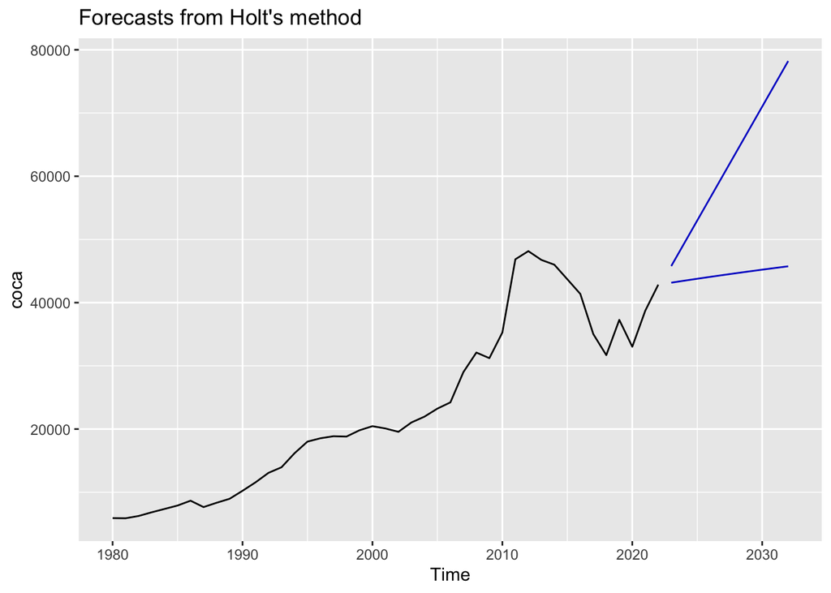

```r
autoplot(pronostico_coca, PI=FALSE) +
  autolayer(pronostico_coca2, PI=FALSE)
```

Exportar estos resultados, usamos la funcion write.csv, ponemos el nombre del objeto que deseamos exportar, y luego el nombre del archivo nuevo que contendrá estos datos.

```r
write.csv(pronostico_coca, "pronostico coca-cola.csv")
write.csv(pronostico_coca2, "pronostico coca-cola alternativo.csv")
```